# Validation

# Observed vs expected plot

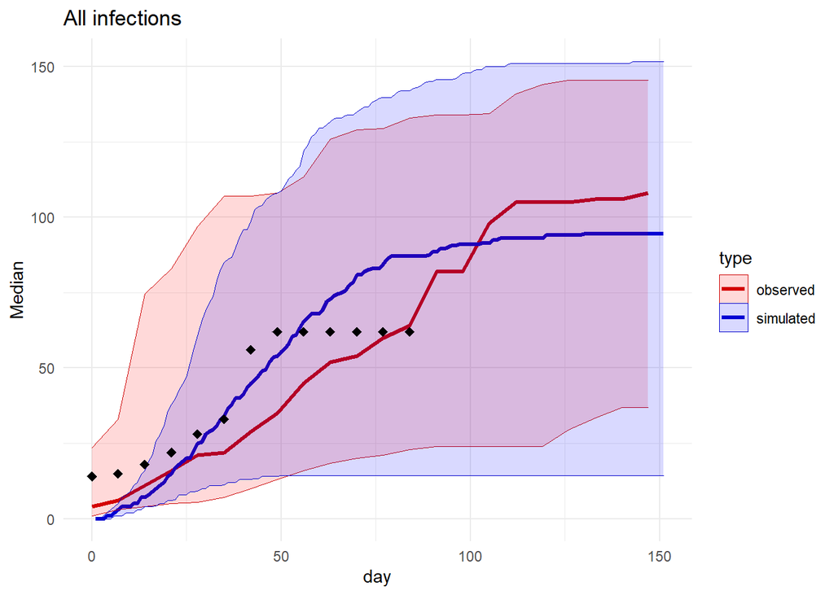

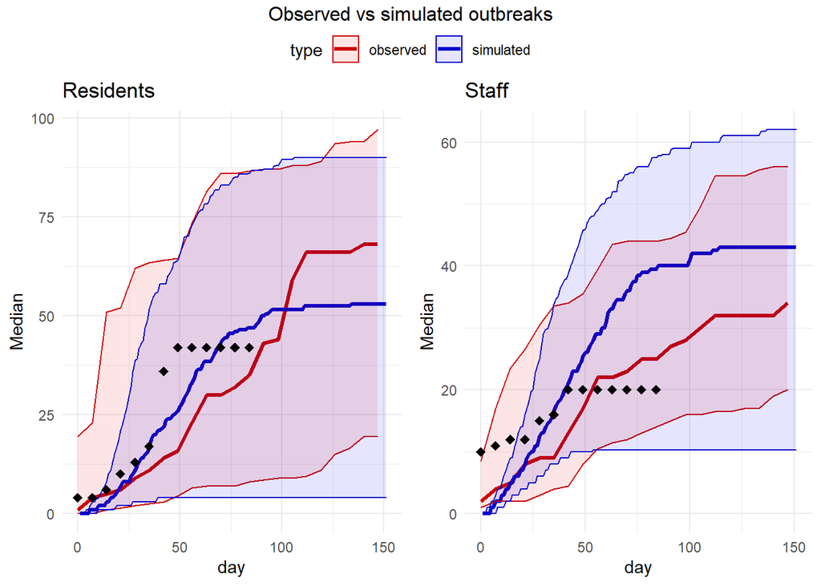

# Correlation of observed and expected

## Using the median

I calculated the correlation between the median number of infected for the simulated and observed cases, and used a simple linear regression where: $Observed\sim Simulated$ and obtained the $R^2$.

| Model | $\rho$ | $R^2$ |
| --- | --- | --- |
| Total Infected | 0.9221291 | 0.8503221 |
| Infected Residents | 0.908348 | 0.8250961 |
| Infected Staff | 0.9804931 | 0.9613668 |

## Using a simple linear regression fro individual observations.

To calculate the $R^2$ we used model

$$Y_i\sim X_1+X_2+X_3$$
Where:

- $Y_i$ represent the cumulative number of infected.
- $X_1$ if its from an observed or simulated outbreak.
- $X_2$ the day since the outbreak.
- $X_3$ the number of simulation or outbreak ID.

We did a model for the cumulative number of residents infected, cumulative number of staff infected, and total cumulative number of infected (residents+staff).

| $Y_i$ | $R^2$ |
| --- | --- |
| Total Infected | 0.7963542 |
| Infected residents | 0.7992968 |
| Infected Staff | 0.7910985 |

## Using a LMM to calculate a pseudo $R^2$

[output not shown]

My interpretation of this would be:  
A low marginal $R^2$ indicates that there is not much variation being explained by the fixed effects, which in our model is the type of outbreak (either simulated or observed), indicating that the model can not tell the difference when an outbreak is simulated or observed. This will indicate that our simulation model is good when replicating observed outbreaks.  
A high conditional $R^2$ indicates that most of the variation is being explained by the random effect